# Walk-through for the analyses of a Generalizability Study

The purpose of this walk-through is to introduce and document the analyses in R.

For this walk-through the packages `lme4` (Bates et al. 2015), `tidyverse` (Wickham et al. 2019) and `dplyr` (Wickham et al. 2021) are used.

```r
library(dplyr)
library(tidyverse)
library(lme4)
```

```r
library(readr)
Data <- read_csv("https://osf.io/h2fcw/download")
```

# The mixed effects model

In the manuscript we present several analyses that all have the same statistical mixed effects model at it’s core. The model can be written as

$$y_{wsp} = \beta_0 * Cons + \beta_1 * Copytask_p + (\nu_{0p} + \mu_{0ps} + \psi_{0w} + \epsilon_{0psw})$$

with $y_{wsp}$ being the score of a pause time $y$ for a certain word $w$, in a sentence $s$ written by participant $p$. In the model we add the variable $Copytask_p$ as a fixed effect to control for motor skills of participants.

We expect that pause times depend on the facets:

- **p** (participant) reflected in the participant-specific deviation towards the intercept $\nu_{0p}$
- **s** (sentence) reflected in the sentence-specific deviation towards the intercept $\mu_{0ps}$
- **w** (word) reflected in the word-specific deviation towards the intercept $\psi_{0w}$

All interactions between these facets are captured in the residual term $\epsilon_{0psw}$.

In the dataset the following variable names are used for these variables:

- `copy_task`
- `participant_ID`
- `sentence_ID`
- `word_ID`

In what follows we will present the code for the different analyses presented in the manuscript. The analyses for the first generalizability study concerning all words are described in more detail. For the other analyses similar steps are taken so we will simply present the code so all the analyses can be replicated.

# All words

## Between words

### Estimate the variances

The variable `between_words` contains the pause times between words. To estimate the model the function `lmer()` from the package `lme4` is used.

With `print(VarCorr(Model_between_words), comp = "Variance", digits = 4)` the estimates of the variances based on the linear mixed effects model are extracted.

```r
Model_between_words <-
  lmer(between_words ~ 1 +
                    copy_task +
                    (1|participant_ID) +
                    (1|sentence_ID) +
                    (1|word_ID),
                  data=Data,
                  REML = F)

print(VarCorr(Model_between_words),
      comp = "Variance",
      digits = 4)
```

```
 Groups         Name        Variance
 word_ID        (Intercept) 4412600.4
 participant_ID (Intercept)  110701.0
 sentence_ID    (Intercept)     936.3
 Residual                   1937654.3
```

### Calculate the G coefficient

Now that we have estimated the variances we can use these variance estimates to calculate the Generalizability coefficient. For this calculation we make use of *formula 2* from the manuscript. The calculation is as follows in R:

```r
G_all_bw <- 110701.0 /
  (110701.0 +
    (936.3/27) +
    (4412600.4/650) +
    (1937654.3/(4.75*27))
   )

G_all_bw
```

```
[1] 0.8346433
```

So the resulting generalizability score for the differences between the participants is 0.83 .

### D study

The D study builds on the G study. *Formula 2* from the manuscript is used. First we create an object called `Nsentences` that contains integers from 1 to 40. In the calculations we replace the number 27 by this object to calculate 40 G coefficients dependent on the number of sentences going from 1 sentence to 40 sentences. The results are stored in the object `G_all_bw_sim`.

```r
Nsentences <- 1:40

G_all_bw_sim <- 110701.0 /
  (110701.0 +
    (936.3/Nsentences) +
    (4412600.4/650) +
    (1937654.3/(4.75*Nsentences))
   )
```

With this information we can create the plot that is used in the manuscript.

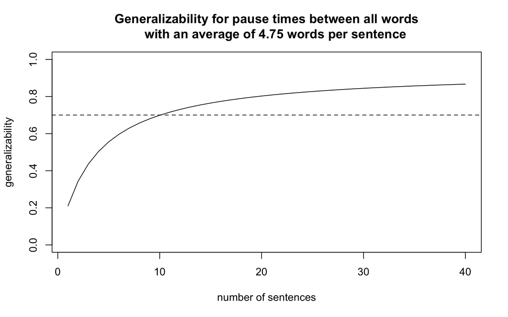

```r
plot(x = Nsentences, y = G_all_bw_sim,
  type = 'l',
  xlab = "number of sentences",
  ylab = "generalizability",
  ylim = (0:1),
  main = "Generalizability for pause times between all words
     with an average of 4.75 words per sentence"
)

abline(h=0.7, lty=2)
```

## Within words

### Estimate the variances

```r
Model_within_words <-
  lmer(within_words ~ 1 +
         copy_task +
         (1|participant_ID) +
         (1|sentence_ID) +
         (1|word_ID),
       data = Data,
       REML = F)

print(VarCorr(Model_within_words),
      comp = "Variance",
      digits = 4)
```

```
 Groups         Name        Variance
 word_ID        (Intercept)  2504.24
 participant_ID (Intercept)  4068.67
 sentence_ID    (Intercept)    36.48
 Residual                   26288.40
```

### Calculate the G coefficient

```r
G_all_within <- 4068.67 /
  (4068.67 +
     (36.48/27)+
     (2504.24/697)+
     (26288.40/(4.75*27))
   )

G_all_within
```

```
[1] 0.9509367
```

### D Study

```r
Nsentences <- 1:40

G_all_within_sim <- 4068.67 /
  (4068.67 +
    (36.48/Nsentences) +
    (2504.24/697) +
    (26288.40/(4.75*Nsentences))
   )
```

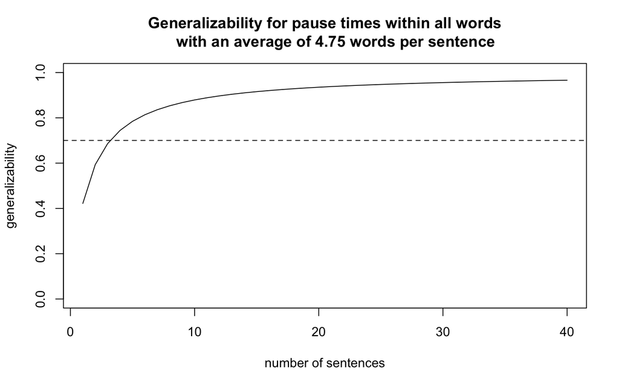

```r
plot(Nsentences,
  G_all_within_sim,
  type = 'l',
  xlab = "number of sentences",
  ylab = "generalizability",
  ylim = (0:1),
  main = "Generalizability for pause times within all words
     with an average of 4.75 words per sentence")

abline(h=0.7,lty=2)
```

# Nouns

An object is created with the data on Nouns only by the following code.

```r
Nouns <- filter(Data, word_class == "NOUN")
```

## Between words

### Estimate the variances

```r
Model_between_words_nouns <- lmer(
  between_words ~ 1 +
    copy_task +
    (1|participant_ID) +
    (1|sentence_ID) +
    (1|target_noun),
  data = Nouns,
  REML = F)

print(VarCorr(Model_between_words_nouns),
      comp = "Variance",
      digits = 7)
```

```
 Groups         Name        Variance
 participant_ID (Intercept)  217859.57
 target_noun    (Intercept)   63572.77
 sentence_ID    (Intercept)       0.00
 Residual                   2700891.49
```

### Calculate the G coefficients

```r
G_nouns_bw <- 217859.57 /
  (217859.57 +
    (0/27) +
    (63572.77/70) +
    (2700891.49/(1.75*27))
   )
G_nouns_bw
```

```
[1] 0.789548
```

### D Study

```r
Nsentences <- 1:40

G_nouns_bw_sim <-
  217859.27 /
   (217859.27 +
   (0/Nsentences) +
   (63572.77/70) +
   (2700891.49/(1.75*Nsentences)))
```

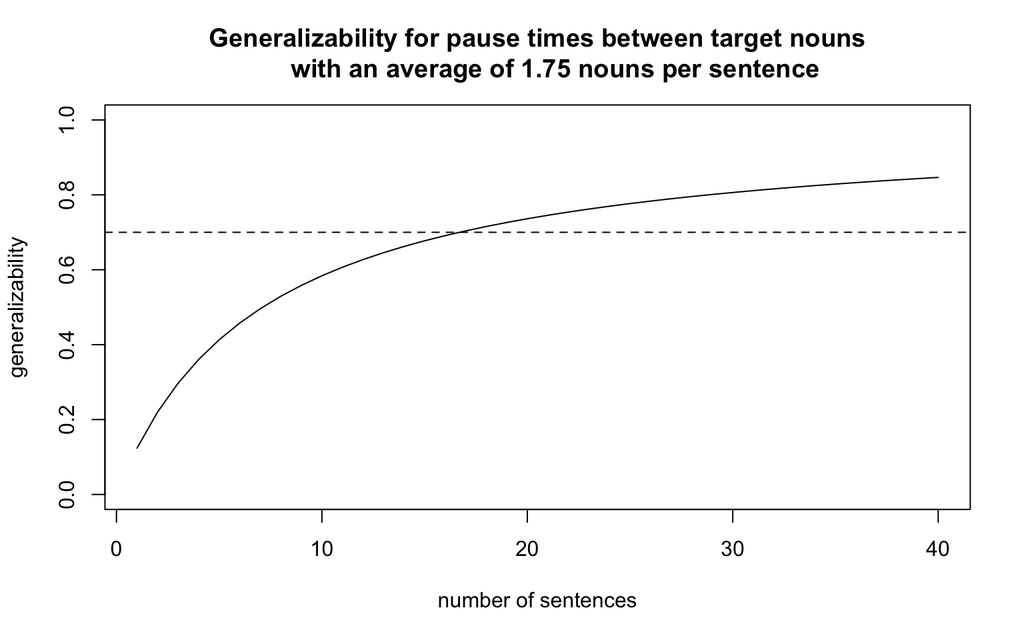

```r
plot(Nsentences,
  G_nouns_bw_sim,
  type = 'l',
  xlab = "number of sentences",
  ylab = "generalizability",
  ylim = (0:1),
  main = "Generalizability for pause times between target nouns
     with an average of 1.75 nouns per sentence")

abline(h=0.7,lty=2)
```

## Within words

### Estimate the variances

```r
Model_within_words_nouns <-lmer(
  within_words ~ 1 +
    copy_task +
    (1|participant_ID) +
    (1|sentence_ID) +
    (1|target_noun),
  data=Nouns,
  REML = F)

print(VarCorr(Model_within_words_nouns),
      comp = "Variance",
      digits = 7)
```

```
 Groups         Name        Variance
 participant_ID (Intercept)  3403.78947
 target_noun    (Intercept)  1585.30854
 sentence_ID    (Intercept)    52.90428
 Residual                   16211.28364
```

### Calculate the G coefficient

```r
G_nouns_wi <- 3403.8/
  (3403.8+
     (52.9/27) +
     (1585.3/70) +
     (16211.3/(1.75*27))
   )

G_nouns_wi
```

```
[1] 0.902505
```

### D Study

```r
Nsentences<-1:40
G_nouns_wi_sim <- 3403.8 /
  (3403.8 +
     (52.9/Nsentences) +
     (1585.3/70) +
     (16211.3/(1.75*Nsentences))
   )
```

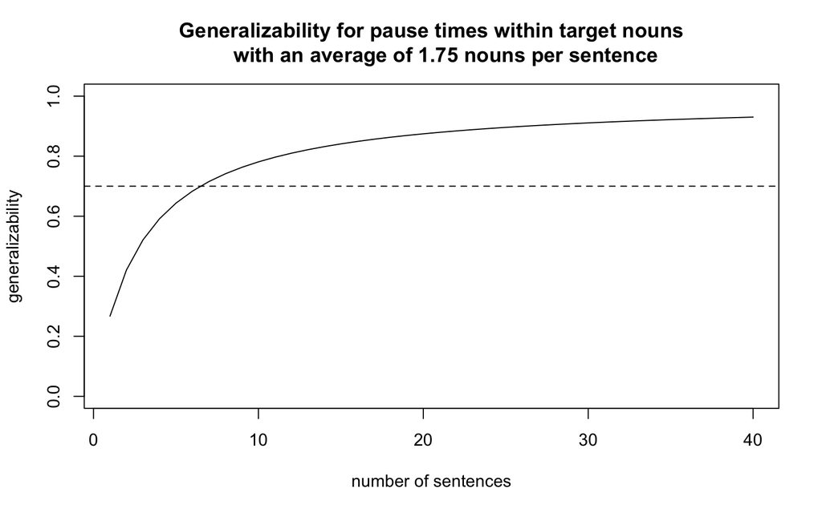

```r
plot(Nsentences,
  G_nouns_wi_sim,
  type = 'l',
  xlab = "number of sentences",
  ylab = "generalizability",
  ylim = (0:1),
  main = "Generalizability for pause times within target nouns
     with an average of 1.75 nouns per sentence")

abline(h=0.7,lty=2)
```

# Verbs

```r
Verbs <- filter(Data, word_class=="VERB")
```

## Between words

### Estimate the variances

```r
Model_between_words_verbs <- lmer(
  between_words ~ 1 +
    copy_task +
    (1|participant_ID) +
    (1|sentence_ID) +
    (1|target_verb),
  data=Verbs,
  REML = F)

print(VarCorr(Model_between_words_verbs),
      comp = "Variance",
      digits = 6)
```

```
 Groups         Name        Variance
 participant_ID (Intercept)   72092.73
 sentence_ID    (Intercept)    2381.46
 target_verb    (Intercept)   21249.20
 Residual                   1638076.52
```

### Calculate the G coefficient

```r
G_verbs_bw <- 72093/
  (72093 +
     (2381/27) +
     (21249/40) +
     (1638077/(1*27))
   )
G_verbs_bw
```

```
[1] 0.5405005
```

### D Study

```r
Nsentences <- 1:80

G_verbs_bw_sim <- 72093/
  (72093 +
     (2381/Nsentences) +
     (21249/40) +
     (1638077/(1*Nsentences))
   )
```

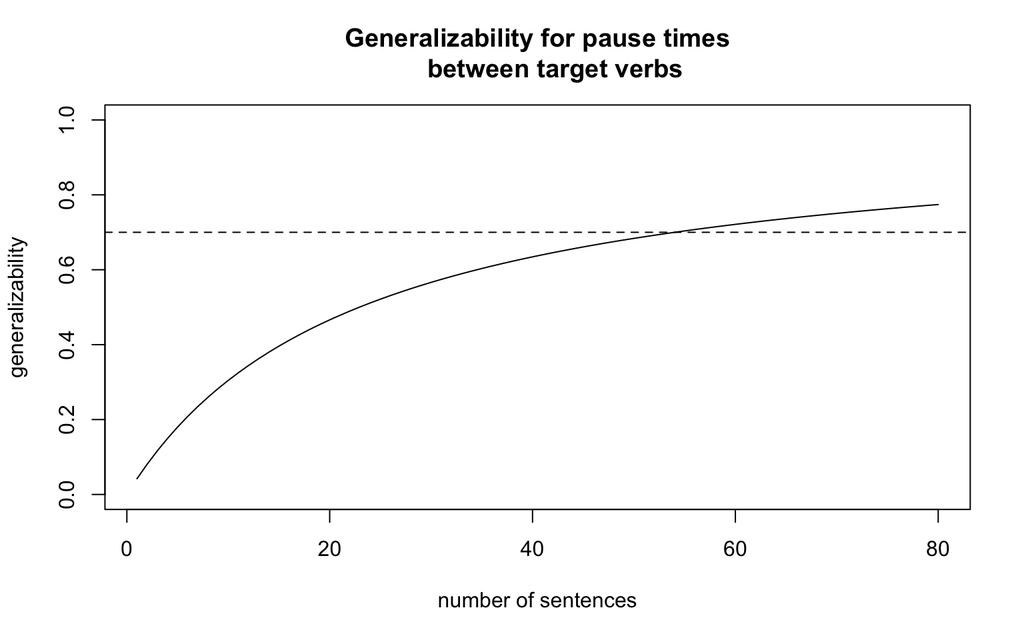

```r
plot(Nsentences,
  G_verbs_bw_sim,
  type = 'l',
  xlab = "number of sentences",
  ylab = "generalizability",
  ylim = (0:1),
  main = "Generalizability for pause times
     between target verbs")

abline(h=0.7,lty=2)
```

## Within words

### Estimate the variances

```r
Model_within_words_verbs <- lmer(
  within_words ~ 1 +
    copy_task +
    (1|participant_ID) +
    (1|sentence_ID) +
    (1|target_verb),
  data=Verbs,
  REML = F)

print(VarCorr(Model_within_words_verbs),
      comp = "Variance",
      digits = 6)
```

```
 Groups         Name        Variance
 participant_ID (Intercept)  3838.52
 sentence_ID    (Intercept)     0.00
 target_verb    (Intercept)  1472.12
 Residual                   14694.66
```

### Calculate the G coefficient

```r
G_verbs_wi <- 3838.52 /
  (3838.52 +
     (0/27) +
     (1472.12/40) +
     (14694.66/(1*27))
   )
G_verbs_wi
```

```
[1] 0.868528
```

### D Study

```r
Nsentences <- 1:40

G_verbs_wi_sim <- 3838.52 /
  (3838.52 +
     (0/Nsentences) +
     (1472.12/40) +
     (14694.66/(1*Nsentences))
   )
```

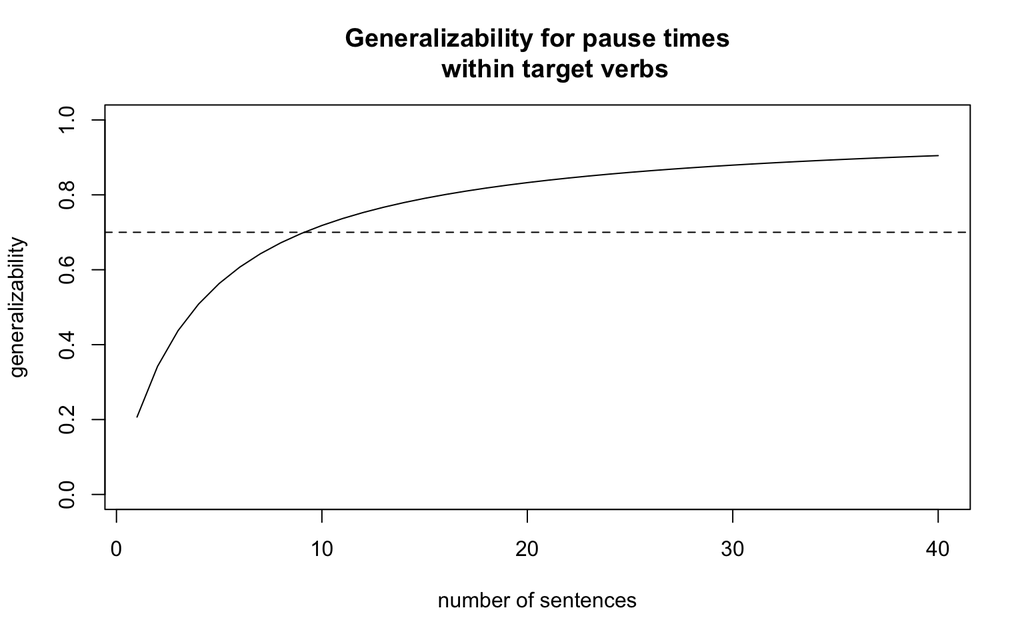

```r
plot(Nsentences,
  G_verbs_wi_sim,
  type = 'l',
  xlab = "number of sentences",
  ylab = "generalizability",
  ylim = (0:1),
  main = "Generalizability for pause times
     within target verbs")

abline(h=0.7,lty=2)
```

# References

Bates, Douglas, Martin Mächler, Ben Bolker, and Steve Walker. 2015. “Fitting Linear Mixed-Effects Models Using Lme4.” *Journal of Statistical Software* 67 (1): 1–48. https://doi.org/10.18637/jss.v067.i01.

Wickham, Hadley, Mara Averick, Jennifer Bryan, Winston Chang, Lucy D’Agostino McGowan, Romain François, Garrett Grolemund, et al. 2019. “Welcome to the tidyverse.” *Journal of Open Source Software* 4 (43): 1686. https://doi.org/10.21105/joss.01686.

Wickham, Hadley, Romain François, Lionel Henry, and Kirill Müller. 2021. *Dplyr: A Grammar of Data Manipulation*. https://CRAN.R-project.org/package=dplyr.